# Ground Truth Establishment for Nuclei Count Cell Cluster Analysis

David Kleinhans

Goethe University Frankfurt am Main

Dezember 06, 2017

# 1 Ground Truth Design

To assess the quality of the *ClusterAnalysis* algorithm for nuclei detection the ground truth was designed as follows.

## 1.1 Model design

- each CellCluster (CC) consists of a number of objects (cells)
- each object is part of the respective CC and defines one cell entity
- each object is determined via a fluorescent nucleus label
- embryos are mounted within a 3D mold to reduce noise

Imaging conditions

| **Condition** |  |
| --- | --- |
| XY scale | 0.32 px/$\mu$m |
| Z-spacing | 4 $\mu$m |
| Camera | Rolera |

## 1.2 Training data

The training set consists of three randomly picked wildtype PLLps. For each the algorithm is run with standard parameterse and all cell cluster rois and nuclei multi point labels are edited manually to get to the ground truth data.

## 1.3 Test data

To test the algorithm it is run at different nuclei detection thresholds on the same image data.

## 1.4 Evaluation

- Nuclei count
  - False positives
  - False negatives

# 2 Results

## 2.1 Image Analysis

For image analysis a custom IJ macro script was developed that segments individual cell clusters based on morphological filtering<sup>1</sup>, gaussian blurring and subsequent thresholding. The user is then presented the segmentation ROIs to manually edit them, if necessary. Using those ROIs as masks, the nuclei within them are count based on gaussian blurring and a 2-D maxima finder. To detect the right amount of nuclei however, it is necessary to evaluate the distance over which the blurring should be applied.

### 2.1.1 Macro modules

The macro developed consists of the following main modules:

1. Background subtraction, morphological filtering, gaussian blurring & segmentation
2. Manual correction for cell cluster segmentation masks
3. ROI indexing from left (1) to right (n)
4. Nuclei counting within cell cluster masks
5. Export of results table (Area, Count, …)

#### 2.1.1.1 Registered data

Figure 1 shows a registered maximum Z projected lateral line used for ground truth evaluation.

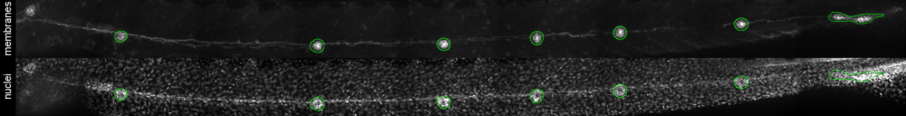

**Figure 1:** Registered, Maximum Z projected data

#### 2.1.1.2 Ground Truth data

Figure 2 shows the single registered cell clusters from figure 1 and the manually labeled nuclei within.

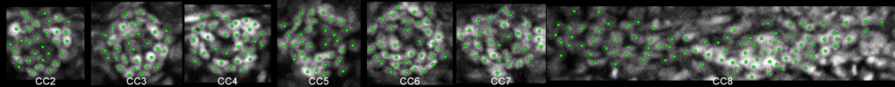

**Figure 2:** Cell count P05

## 2.2 Data Analysis

All data processing has been done in R studio using R. The code is provided below.

### 2.2.1 Import data

Define categories and cooerce to list

```r
ident <- as.character(list("GrT", "NB45", "NB50", "NB55", "NB60", "NB70", "NB80")) #has to match table names exactly
```

Import data

```r
library(plyr)
library(dplyr)
setwd("Data/03 - Results/")
fl <- c()
for (i in 1:length(ident)) {
  fl[[i]] <- list.files(".", pattern=ident[i], full.names=FALSE)
  #id <- paste("fl", ident[i], sep = "_")
  #assign(id, fl[[i]])
  Group <- ident[i]
  temp <- ldply(fl[[i]], read.data.all)
  id <- paste(ident[i], "CC", sep = "_")
  assign(id, temp)
  rm(id, Group)
}
save.image(file="D:/David/RNotes/GroundTruth2D/GroundTruth2D.RData")
```

### 2.2.2 Nuclei Count

Comparing the segmented objects count of the threshold levels with the ground truth gives an indication for over- resp. under-segmentation. In figure 5 the relative numbers for each threshold level can be seen in percentage above or below the mean cell count of the ground truth (blue horizon). Analogous to the graphical inspection, the magenta area represents over-segmentation, the green under-segmentation. Additionally, table ‘cell counts’ shows the absolute numbers.

```r
library(data.table)
library(plyr)
# relative difference
GrT <- GrT_CC[c(20:23)]
GrT$diff <- (GrT_CC$Nuclei-GrT_CC$Nuclei)/GrT_CC$Nuclei
NB45 <- NB45_CC[c(20:23)]
NB45$diff <- (NB45_CC$Nuclei-GrT_CC$Nuclei)/GrT_CC$Nuclei
NB50 <- NB50_CC[c(20:23)]
NB50$diff <- (NB50_CC$Nuclei-GrT_CC$Nuclei)/GrT_CC$Nuclei
NB55 <- NB55_CC[c(20:23)]
NB55$diff <- (NB55_CC$Nuclei-GrT_CC$Nuclei)/GrT_CC$Nuclei
NB60 <- NB60_CC[c(20:23)]
NB60$diff <- (NB60_CC$Nuclei-GrT_CC$Nuclei)/GrT_CC$Nuclei
NB70 <- NB70_CC[c(20:23)]
NB70$diff <- (NB70_CC$Nuclei-GrT_CC$Nuclei)/GrT_CC$Nuclei
NB80 <- NB80_CC[c(20:23)]
NB80$diff <- (NB80_CC$Nuclei-GrT_CC$Nuclei)/GrT_CC$Nuclei
# bind
NB_all_diff <- rbind(NB45, NB50, NB55, NB60, NB70, NB80)
NB_all_mean <- rbind(GrT, NB45, NB50, NB55, NB60, NB70, NB80)
# clean env
rm(GrT, NB45, NB50, NB55, NB60, NB70, NB80)
# calculate mean
NB_all_diff_mean <- ddply(NB_all_diff, .(Group), summarize,
                      mean_diff = mean(diff, na.rm=TRUE),
                      sd_diff = sd(diff, na.rm=TRUE))
# multiply mean and diff by 100 for percentage
NB_all_diff_mean$mean_diff <- NB_all_diff_mean$mean_diff*100
NB_all_diff_mean$sd_diff <- NB_all_diff_mean$sd_diff*100
# save
save.image(file="D:/David/RNotes/GroundTruth2D/GroundTruth2D.RData")
```

[figure not shown]

**Figure 5:** Relative difference of segment counts (N=3, Errorbars = Std./2)

Absolute numbers nuclei counts

| Group | GrT | NB45 | NB50 | NB55 | NB60 | NB70 | NB80 |
| --- | --- | --- | --- | --- | --- | --- | --- |
| mean_nuclei | 40.95238 | 52.80952 | 45.76190 | 41.90476 | 38.57143 | 34.61905 | 31.33333 |
| sd_nuc | 21.52551 | 27.90093 | 22.03158 | 20.50830 | 18.75252 | 16.34465 | 14.77949 |

#### 2.2.2.1 Precision / Recall

[figure not shown]

**Figure 6:** precision and recall. Precision is the average probability of relevant retrieval, Recall is the average probability of complete retrieval.[wiki](https://en.wikipedia.org/wiki/Precision_and_recall)

[figure not shown]

NB60

[figure not shown]

NB60

# References

1. Legland, D., Arganda-Carreras, I. & Andrey, P. MorphoLibJ: Integrated library and plugins for mathematical morphology with ImageJ. *Bioinformatics* (2016). doi:10.1093/bioinformatics/btw413